# MBTA Performance Data

Shawn Connor, Jeff Cunningham, Danielle Feng and Varuni Gang

Friday May 6, 2016

#### *CSCI E-107 Final Project*

#### https://github.com/TaleOfTwoTransportationSystems/DataProject

### The Project

[video not shown]

The MBTA is the greater Boston area’s traditional public transit system with over 1 million riders per typical weekday. It is comprised of subway trains, longer reach commuter trains, buses and ferries. Since 2009, the MBTA has made available a large amount of data regarding trips on the system, including alerts. The real time alerts are scraped and then Tweeted by CodeForBoston.

While pursing another project (which also related to public transit in Boston), we ran into roadblocks with data availability but had the good fortune to find an exciting new API from MBTA Developers which was just recently made accessible to the public; so recently in fact that we’re not sure it’s been officially announced yet outside the MBTA Developer forum post where they told us about it (the API specification they shared is still stamped with a big “DRAFT” on the cover, which was kind of cool).

Using this API, as well as the CodeForBoston tweets, we were able to conduct some interesting data sourcing, exploration, and visualization. The Twitter-sourced MBTA alerts give us both temporal and geographic insights into where problems may be occuring, and the MBTA-sourced data on train movements allow us to see both specific incidents in the T system and broad patterns in service quality throughout it. We hope that this project will be a good demonstration of what this new MBTA source contains, the sorts of insights it may allow, and the research it might enable, with the connection to Twitter alerts being a first example of how to enrich it even further.

### Related work

An impressive set of MBTA visualizations from a pair of WPI graduate students (at the time). Their initial work was done before the MBTA offered historical performance (actual arrival/departure times), so they had to build a system to collect and store the MBTA’s realtime data in real time before starting in on their analysis. They were also able to get ridership information directly from the MBTA (which is still not availble from the MBTA’s API).

- https://mbtaviz.github.io/

Thesis on MBTA performance metrics:

- https://dspace.mit.edu/handle/1721.1/99541

### Data

The MBTA’s [GTFS] (https://developers.google.com/transit/gtfs/) archive was a little intimidating because the data is scatter across several CSVs, but is still a good source of schedule information. Alerts are not part of the GTFS archive, but are sent out on Twitter (originally by a third-party bot). Fetching from this source only allows us to get the last 3200 tweets, but the alerts are infrequent enough for that to be a reasonable window; we were able to go back to 2015. The new MBTA performance API allows for pulling down historical data, including actual arrivals, departures and headways, back to mid-2015. Unfornately ridership information (such as turnstile metrics or fare collections) is not yet available through the APIs – previous ridership studies were done in partnership with the MBTA, where they provided the ridership data directly.

**MBTA Archive (2009-)**

- https://goo.gl/pgupka
- http://www.mbta.com/gtfs_archive/archived_feeds.txt
- https://developers.google.com/transit/gtfs/

**MBTA Alerts Twitter Feed (last 3200 tweets)**

- https://twitter.com/mbta_alerts
- https://twitter.com/mbta?lang=en
- https://cran.r-project.org/web/packages/twitteR/index.html
- http://bigcomputing.blogspot.com/2016/02/the-twitter-r-package-by-jeff-gentry-is.html
- May ask @CodeForBoson to download their entire feed.

**MBTA Performance Data (July 2015+)**

- https://goo.gl/M6G4MZ

### The Results

We used the MBTA’s new API to fetch data for both travel times and headways. Travel Times consist of one record (row) for each time a train went from one stop to another. Headways track the time between departures at a given station. When trains are running late, headways exceed their benchmark targets. The root causes of slow service can probably be better picked apart from travel times and dwell times, but the eventual impact to riders is most cleanly seen in headways. In structure and access, this data is very similar to the travel times data, with each record representing one train leaving a station.

Here’s what a raw block of travel times data from the MBTA’s new API looks like:

| route_id | direction | dep_dt | arr_dt | travel_time_sec | benchmark_travel_time_sec | threshold_flag_1 | threshold_flag_2 | threshold_flag_3 |
| --- | --- | --- | --- | --- | --- | --- | --- | --- |
| Red | 0 | 1453717691 | 1453717793 | 102 | 120 | NA | NA | NA |
| Red | 0 | 1453718308 | 1453718390 | 82 | 120 | NA | NA | NA |
| Red | 0 | 1453718587 | 1453718696 | 109 | 120 | NA | NA | NA |
| Red | 0 | 1453720076 | 1453720223 | 147 | 120 | NA | NA | NA |
| Red | 0 | 1453720838 | 1453720998 | 160 | 120 | NA | NA | NA |
| Red | 0 | 1453721192 | 1453721491 | 299 | 120 | NA | NA | NA |

And here are some headways:

| route_id | prev_route_id | direction | current_dep_dt | previous_dep_dt | headway_time_sec | benchmark_headway_time_sec | threshold_flag_1 | threshold_flag_2 | threshold_flag_3 |
| --- | --- | --- | --- | --- | --- | --- | --- | --- | --- |
| Red | Red | 0 | 1453718308 | 1453717691 | 617 | 405 | threshold_id_01 | threshold_id_02 | NA |
| Red | Red | 0 | 1453718587 | 1453718308 | 279 | 405 | NA | NA | NA |
| Red | Red | 0 | 1453720076 | 1453718587 | 1489 | 420 | threshold_id_01 | threshold_id_02 | threshold_id_03 |
| Red | Red | 0 | 1453720838 | 1453720076 | 762 | 420 | threshold_id_01 | threshold_id_02 | NA |
| Red | Red | 0 | 1453721192 | 1453720838 | 354 | 420 | NA | NA | NA |
| Red | Red | 0 | 1453726531 | 1453725039 | 1492 | 240 | threshold_id_01 | threshold_id_02 | threshold_id_03 |

With some cleaning, we turn this raw data into something we can more easily work with. Here are some examples of what the tables end up looking like and the sorts of columns we have. Most are from the source, a few, like service_dt, we have inferred to make other processing easier.

| direction | dep_dt | arr_dt | travel_time_sec | benchmark_travel_time_sec | from_stop | to_stop | time_delta | lateness | is_weekend | dep_time | stop_name | parent_station_name | heading | stop_seq | service_d |
| --- | --- | --- | --- | --- | --- | --- | --- | --- | --- | --- | --- | --- | --- | --- | --- |
| 0 | 2016-01-25 05:20:13 | 2016-01-25 05:21:23 | 70 | 120 | 70063 | 70065 | -50 | 0 | FALSE | 5.336944 hours | Davis - Inbound | Davis | Southbound | 2 | 2016-01-25 |
| 0 | 2016-01-25 05:22:26 | 2016-01-25 05:23:59 | 93 | 180 | 70065 | 70067 | -87 | 0 | FALSE | 5.373889 hours | Porter - Inbound | Porter | Southbound | 3 | 2016-01-25 |
| 0 | 2016-01-25 05:24:54 | 2016-01-25 05:27:21 | 147 | 180 | 70067 | 70069 | -33 | 0 | FALSE | 5.415000 hours | Harvard - Inbound | Harvard | Southbound | 4 | 2016-01-25 |
| 0 | 2016-01-25 05:28:11 | 2016-01-25 05:29:53 | 102 | 120 | 70069 | 70071 | -18 | 0 | FALSE | 5.469722 hours | Central - Inbound | Central | Southbound | 5 | 2016-01-25 |
| 0 | 2016-01-25 05:29:48 | 2016-01-25 05:30:59 | 71 | 120 | 70063 | 70065 | -49 | 0 | FALSE | 5.496667 hours | Davis - Inbound | Davis | Southbound | 2 | 2016-01-25 |
| 0 | 2016-01-25 05:30:43 | 2016-01-25 05:35:38 | 295 | 120 | 70071 | 70073 | 175 | 175 | FALSE | 5.511944 hours | Kendall/MIT - Inbound | Kendall/MIT | Southbound | 6 | 2016-01-25 |

| direction | current_dep_dt | previous_dep_dt | headway_time_sec | benchmark_headway_time_sec | from_stop | to_stop | time_delta | lateness | is_weekend | dep_time | stop_name | parent_station_name | heading | stop_seq | service_d |
| --- | --- | --- | --- | --- | --- | --- | --- | --- | --- | --- | --- | --- | --- | --- | --- |
| 0 | 2016-01-25 05:29:48 | 2016-01-25 05:20:13 | 575 | 480 | 70063 | 70065 | 95 | 95 | FALSE | 5.496667 hours | Davis - Inbound | Davis | Southbound | 2 | 2016-01-25 |
| 0 | 2016-01-25 05:31:47 | 2016-01-25 05:22:26 | 561 | 405 | 70065 | 70067 | 156 | 156 | FALSE | 5.529722 hours | Porter - Inbound | Porter | Southbound | 3 | 2016-01-25 |
| 0 | 2016-01-25 05:34:20 | 2016-01-25 05:29:48 | 272 | 405 | 70063 | 70065 | -133 | 0 | FALSE | 5.572222 hours | Davis - Inbound | Davis | Southbound | 2 | 2016-01-25 |
| 0 | 2016-01-25 05:34:48 | 2016-01-25 05:24:54 | 594 | 420 | 70067 | 70069 | 174 | 174 | FALSE | 5.580000 hours | Harvard - Inbound | Harvard | Southbound | 4 | 2016-01-25 |
| 0 | 2016-01-25 05:36:26 | 2016-01-25 05:31:47 | 279 | 405 | 70065 | 70067 | -126 | 0 | FALSE | 5.607222 hours | Porter - Inbound | Porter | Southbound | 3 | 2016-01-25 |
| 0 | 2016-01-25 05:38:28 | 2016-01-25 05:28:11 | 617 | 405 | 70069 | 70071 | 212 | 212 | FALSE | 5.641111 hours | Central - Inbound | Central | Southbound | 5 | 2016-01-25 |

As you can see, the data is not terribly complicated, but there is lots of it; the Red Line alone has almost 450,000 travel-time records in the time window we looked at. Here is a simple scatter plot of train departures within our window, just from Porter Square heading inbound.

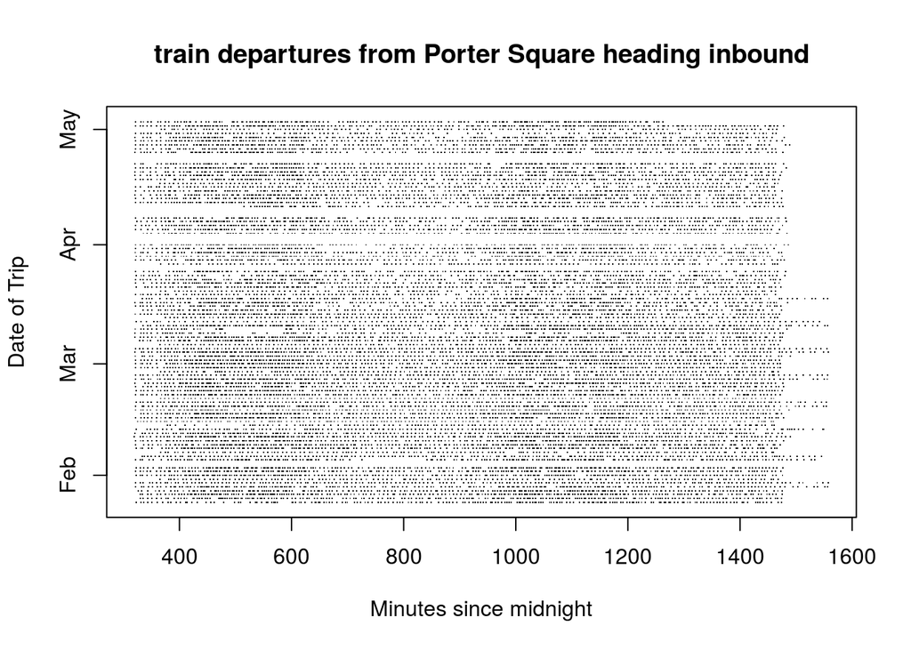

Here’s one using headways, so that we can color-code by how the trains were performing compared to its benchmark time when they departed the station. Positive values indicate a train was running late, and are encoded tending toward pink. Negative values indicate the train was actually running a bit ahead, and are coded in blue.

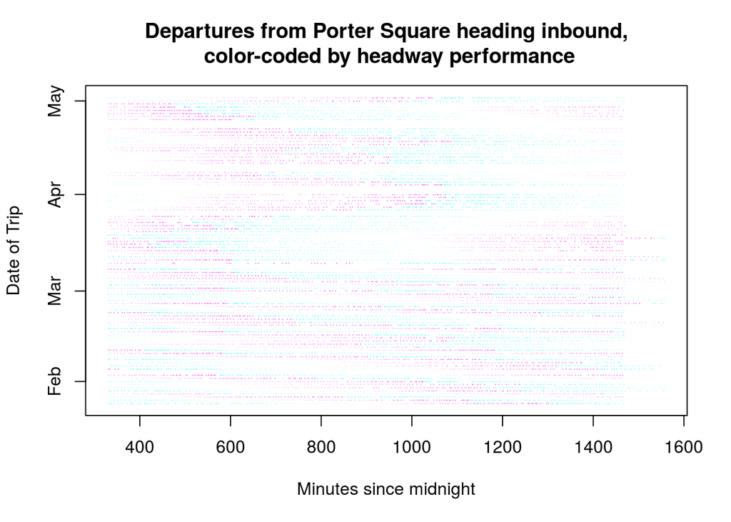

With this simple addition we can start to see patterns in the data. Headway lateness seems to cluster; once it happens in a given day it appears to take a while to sort itself out. Delays tend to happen at the same time of day for several days in a row; this may indicate construction or some other persistent (but not permanent) interruption.

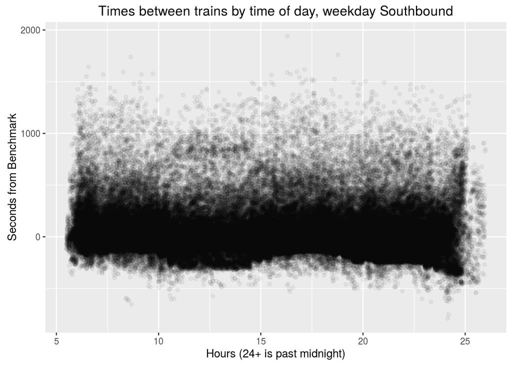

That’s a lot of points! Lets use travel times (the number of seconds between two pairs of stops) to look for some broad trends, by comparing the benchmark time (provided by the MBTA) and the actual time per individual trip, averaged over each minute from January to April. The daily rush hours is highlighted in red (7-9am) and green (5-7pm). This time we pick Park Street’s northbound track (heading to Charles/MGH), a major stop for commuters. The plot is interactive, so you can look in more detail at different points or mouse-over for more information. Note the major spikes in the averages just before (and during) the rush hours, but also note that on average, travel times out of Park Street are, on average, consistently about a minute longer than expected even outside those spikes.

[interactive chart not shown]

Compare Park Street to the next pair out on the line, Charles/MGH to Kendall. There is a noteworthy cyclical pattern in the averages, which actually is at it’s lowest during those same rush hours.

[interactive chart not shown]

Park Street seems like it’s generally pretty slow, while Charles/MGH appears more consistent. Lets take ALL of the stations, and see if there’s evidence of this type difference in other stations.

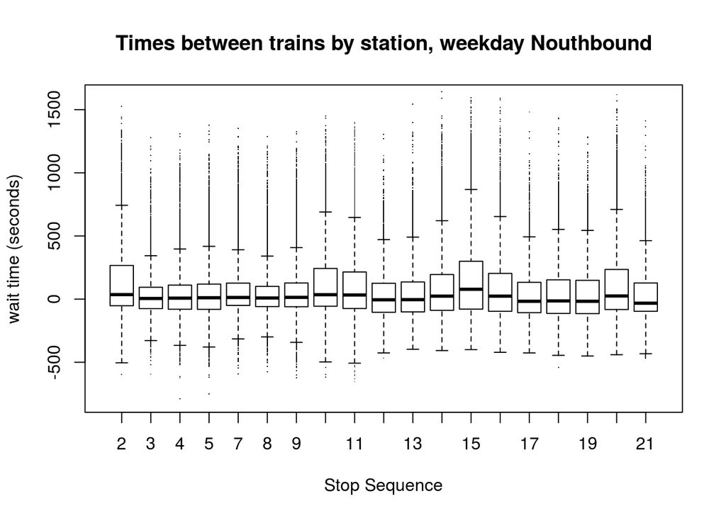

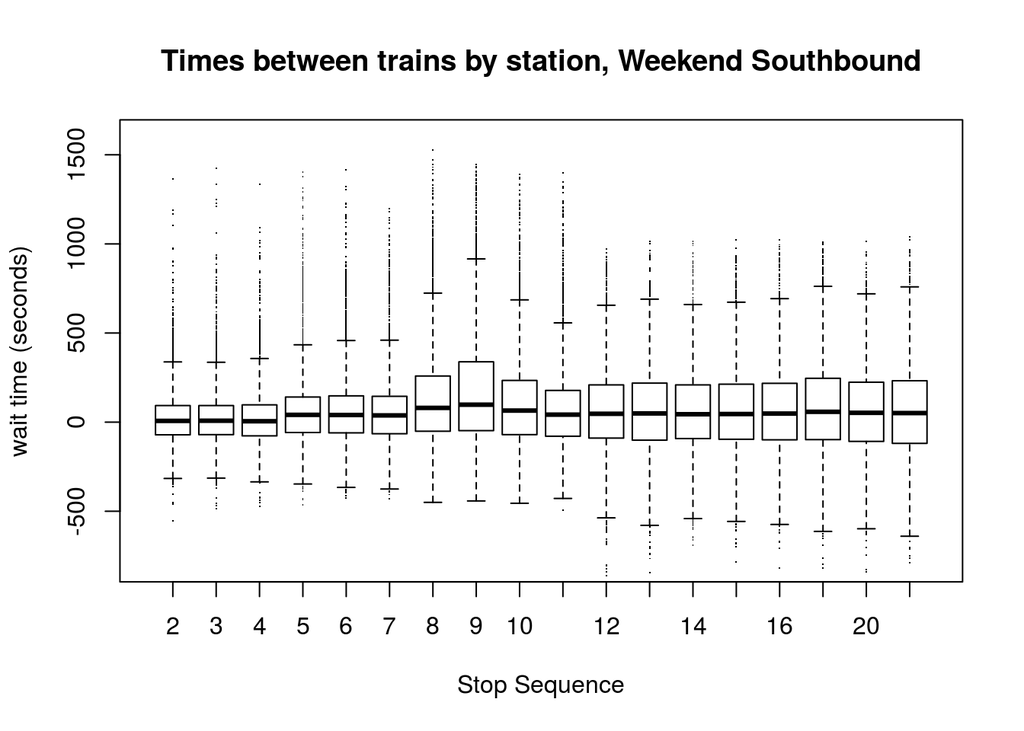

The boxplots makes clear that though much of the data is very close to the benchmark, there are certainly instances where gaps are greater or less than their benchmark times. For reference, Park Street is #8 when on the Southbound plot and #16 Norhtbound.

To get a better sense of the full ranges of the data, lets try a density plot. Here we’re looking at time-deltas for headways by station; there is naturally significant overplotting, but this helps us spot very unusual stations.

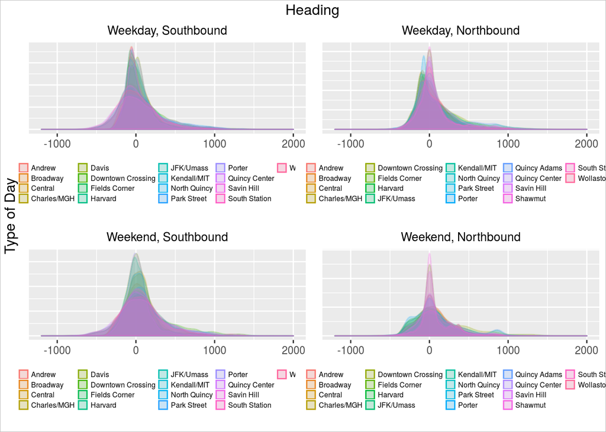

We can see that the distributions tend to skew right; this isn’t a surprise, because there is a limit to how early a train can be, but a much greater limit to how late it can be! We also note that even though the “center mass” of the density plots is very close to 0 (no delay), there are a significant number of late and early trains as well. Weekend northbound trains seem to be the most consistent (density closest to 0), but even there some noteworthy delays can be seen in the plot.

We know that some amount of headway delay can be caused by longer-than-expected times to travel between stations. Let’s look at what northbound, weekday trains’ travel times look like; here we plot densities of travel times, also by station.

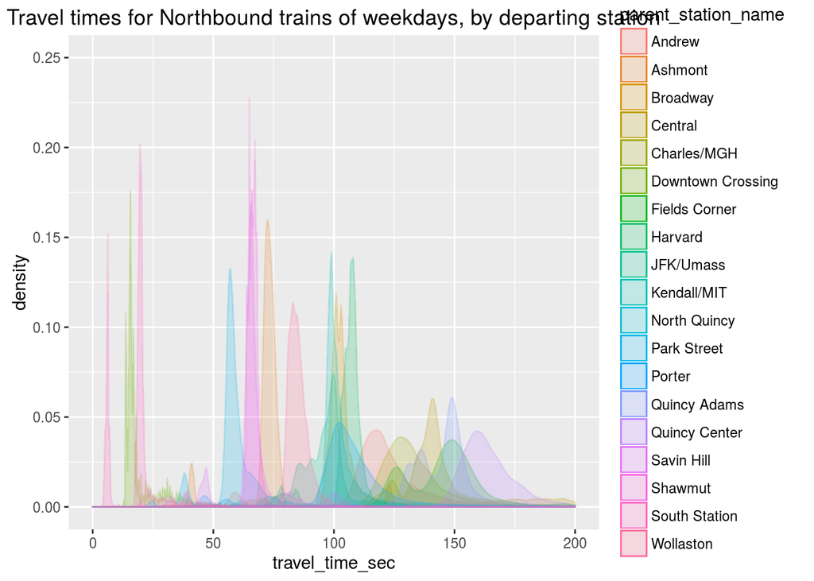

We certainly get less overplotting! This makes sense as any given connection is of different geographic separation, but what’s more interesting is how variable those times appear to be even along fixed routes.

Lets take a look at service quality. One sensible metric would be how long pasengers are waiting on platforms for trains beyond how long they “should” be waiting per normal service. In our data this can be thought of as the difference between the actual observed times and the benchmark times provided by the MBTA. However, we only look for cases where this number is positive; the MBTA gets no extra credit for early trains! This isn’t because we’re mean spirited, it’s because faster-than-expected headways are indistinguishable from just happening to get to the platform at the right time to a typical rider, and because faster-than-expected headways are often the result of backup cause by slowness earlier in the day.

Here’s a simple density plot of ALL observed lateness (on-time or early headways removed) to give an idea of what is typical.

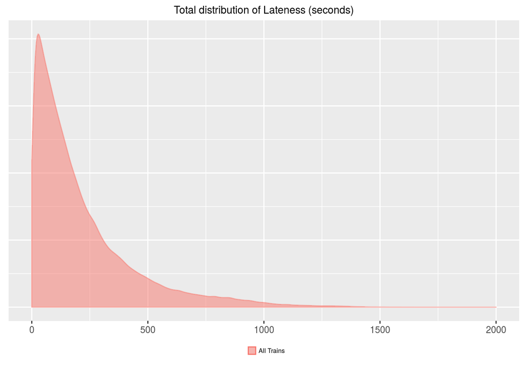

This shape should be familiar; it’s the right-half of the “time-delta” headway distributions above.

Lets see if there are broad patterns by type of day or direction of travel.

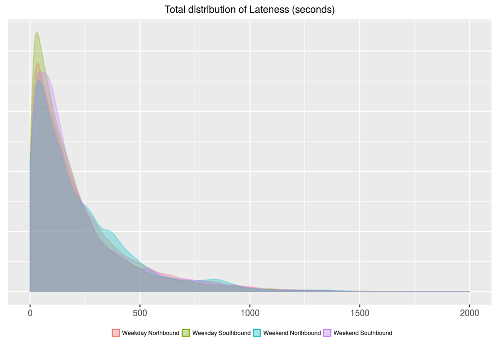

Interesting; it looks like the MBTA’s expected benchmarks are pretty good, in that the they appear to account well for variances by weekend and direction. If they didn’t, the we would expect the distributions to show some systemic bias, but they’re actually pretty similar. The weekday southbound trains tend to have somewhat shorter lateness events, and for weekend northbound they tend to be longer. Note, however, that we can’t say that weekend Northbound tends to be late more often, because we threw out anything that wasn’t lateness already.

What if we wanted a sense of both where **and** when this lateness is most accutely felt? One approach would be to bucket the lateness events, add up the total amount of “overage” in each bucket, and divide by the total time in each bucket. This gives us a metric, “percent late”, which we can think of as “for the entire time we observed the station, for what % of that time was a train past it’s benchmark arrival time? Keep in mind that this may not be a perfect ratio; if trains get really backed up it’s possible that two trains could be sitting at a station simultaneously, allowing us to observe more lateness that the actual clock-time where one ore more trains were late in a given bucket. However, it still makes a reasonable indicator of how behind schedule the system is.